# Lab 4B - Clustering

### 1. Load the Data

1. Import the OS library.

```python
import os
```

2. Set the working directory.

```python
os.chdir("C:\\Workshop\\Data")
```

3. Import the pandas library as "pd".

```python
import pandas as pd
```

4. Read the Rates.csv file into a data frame called *policies*.

```python
policies = pd.read_csv("Rates.csv")
```

### 2. Explore the Data

1. Inspect the *policies* data frame using the `head` function.

```python
policies.head()
```

|  | Gender | State | State_Rate | Height | Weight | BMI | Age | Rate |
| --- | --- | --- | --- | --- | --- | --- | --- | --- |
| 0 | Male | MA | 0.100434 | 184 | 67.8 | 20.025992 | 77 | 0.332000 |
| 1 | Male | VA | 0.141723 | 163 | 89.4 | 33.648237 | 82 | 0.869148 |
| 2 | Male | NY | 0.090803 | 170 | 81.2 | 28.096886 | 31 | 0.010000 |
| 3 | Male | TN | 0.119973 | 175 | 99.7 | 32.555102 | 39 | 0.021532 |
| 4 | Male | FL | 0.110345 | 184 | 72.1 | 21.296078 | 68 | 0.149750 |

2. Import pyplot from matplotlib as "plt".

```python
import matplotlib.pyplot as plt
```

3. Create a scatterplot matrix of the data set.

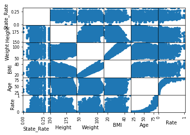

```python
pd.plotting.scatter_matrix(
    frame = policies,
    alpha = 1,
    s = 100,
    diagonal = 'none');
```

4. Question: Do you see any natural clusters in these data? How Many?

### 3. Transform the Data

1. Create a data frame of features for clustering (omit the categorical State column).

```python
X = policies.iloc[:, policies.columns != "State"]
```

2. Inspect the features using the `head` function.

```python
X.head()
```

|  | Gender | State_Rate | Height | Weight | BMI | Age | Rate |
| --- | --- | --- | --- | --- | --- | --- | --- |
| 0 | Male | 0.100434 | 184 | 67.8 | 20.025992 | 77 | 0.332000 |
| 1 | Male | 0.141723 | 163 | 89.4 | 33.648237 | 82 | 0.869148 |
| 2 | Male | 0.090803 | 170 | 81.2 | 28.096886 | 31 | 0.010000 |
| 3 | Male | 0.119973 | 175 | 99.7 | 32.555102 | 39 | 0.021532 |
| 4 | Male | 0.110345 | 184 | 72.1 | 21.296078 | 68 | 0.149750 |

3. Convert the categorical Gender variable {Female, Male} to integers {0, 1}.

```python
X.Gender = X.Gender.apply(lambda x: 0 if x == "Female" else 1)
```

4. Inspect the integer Gender series.

```python
X.Gender.head()
```

```
0    1
1    1
2    1
3    1
4    1
Name: Gender, dtype: int64
```

3. Import the numpy library as "np".

```python
import numpy as np
```

4. Set the random number seed

```python
np.random.seed(42)
```

### 4. Cluster with k-Means

1. Import the k-means class from sklearn.

```python
from sklearn.cluster import KMeans
```

2. Create a k-means model with k = 3 and 10 random initializations.

```python
k_model = KMeans(
    n_clusters = 3,
    n_init = 10)
```

3. Fit the model to the data.

```python
k_model.fit(X)
```

```
KMeans(algorithm='auto', copy_x=True, init='k-means++', max_iter=300,
    n_clusters=3, n_init=10, n_jobs=1, precompute_distances='auto',
    random_state=None, tol=0.0001, verbose=0)
```

4. Create a palette with three colors for each of the tree clusters.

```python
palette = {0:'#fb8072', 1:'#80b1d3', 2:'#b3de69'}
```

5. Map the colors to each of the clusters.

```python
k_colors = pd.Series(k_model.labels_) \
    .apply(lambda x:palette[x])
```

6. Create a scatterplot matrix colored by cluster.

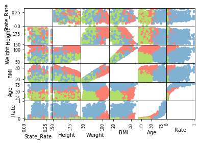

```python
pd.plotting.scatter_matrix(
    frame = policies,
    color = k_colors,
    alpha = 1,
    s = 100,
    diagonal = 'none');
```

7. Question: Do you see any 2D projections of thes data that show each of the clusters clearly separated?

8. Plot a scatterplot of BMI (*y*-axis) vs. Age (*x*-axis) colored by the clusters.  
Superimpose the centroids of each cluster as X's on the scatterplot.

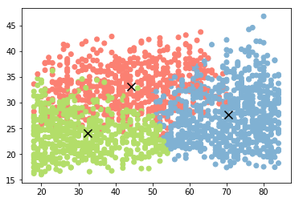

```python
plt.scatter(
    x = policies.Age,
    y = policies.BMI,
    color = k_colors)
plt.scatter(
    x = k_model.cluster_centers_[:,5],
    y = k_model.cluster_centers_[:,4],
    marker = 'x',
    color = "black",
    s = 100)
plt.xlabel = "BMI"
plt.ylabel = "Age"
plt.show()
```

8. Question: What would you call each of these clusters if you had to give them a name based on their common properties?

### 5. Cluster with Hierarchical Clustring

1. Import the agglomerative clustering class from sklearn.

```python
from sklearn.cluster import AgglomerativeClustering
```

2. Create a hierachical cluster model with three clusters.

```python
h_model = AgglomerativeClustering(
    n_clusters = 3)
```

3. Fit the model to the data.

```python
h_model.fit(X)
```

```
AgglomerativeClustering(affinity='euclidean', compute_full_tree='auto',
            connectivity=None, linkage='ward', memory=None, n_clusters=3,
            pooling_func=<function mean at 0x000001F594B640D0>)
```

4. Import the dendrogram function from scipy.

```python
from scipy.cluster.hierarchy import dendrogram
```

5. Plot the dendrogram.

```python
children = h_model.children_

distance = np.arange(children.shape[0])

observations = np.arange(2, children.shape[0] + 2)

linkage_matrix = np.column_stack([children, distance, observations]).astype(float)

dendrogram(
    Z = linkage_matrix,
    leaf_font_size = 8,
    color_threshold = 1939);
```

[output not shown]

7. Map the previous three colors to each cluster.

```python
h_colors = pd.Series(h_model.labels_) \
    .apply(lambda x:palette[x])
```

8. Plot a scatterplot of BMI (*y-axis*) vs. Age (*x-axis*) colored by cluster.

```python
plt.scatter(
    x = policies.Age,
    y = policies.BMI,
    color = h_colors)
plt.xlabel = "Age"
plt.ylabel = "BMI"
plt.show()
```

[output not shown]

9. Question: What is the difference between these two methods of clustering?